# Purchasing Patterns Through Olive Young’s Top 30

## Plot1. Rank vs Price

After analysing the data from Olive Young Global’s Top 30 best sellers, I did not find a clear direct relationship between ranking and price. For example, some expensive products costing over $400 were still ranked within the top 30, while lower-priced products did not always appear at the very top of the ranking. This suggests that global customers do not necessarily consider price as the most important factor when choosing products.

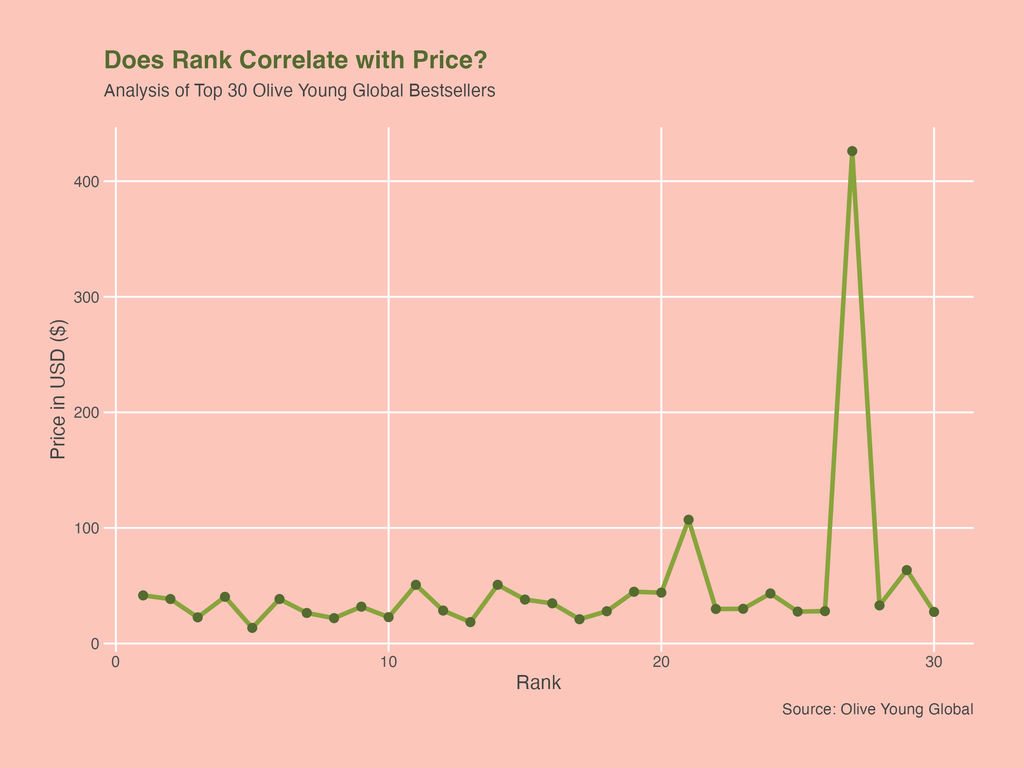

A line graph showing the relationship between bestseller rank and price for Olive Young Global’s top 30 products.

## Plot2. Rank vs Category

If price is not the deciding factor, then what influences purchasing behaviour the most? Based on the visualisations, product category appeared to have a much stronger impact on rankings.

Suncare products dominated the very top positions (ranks 1–3), showing extremely strong popularity, while skincare products were distributed more evenly across the ranking and consistently maintained a strong presence overall.

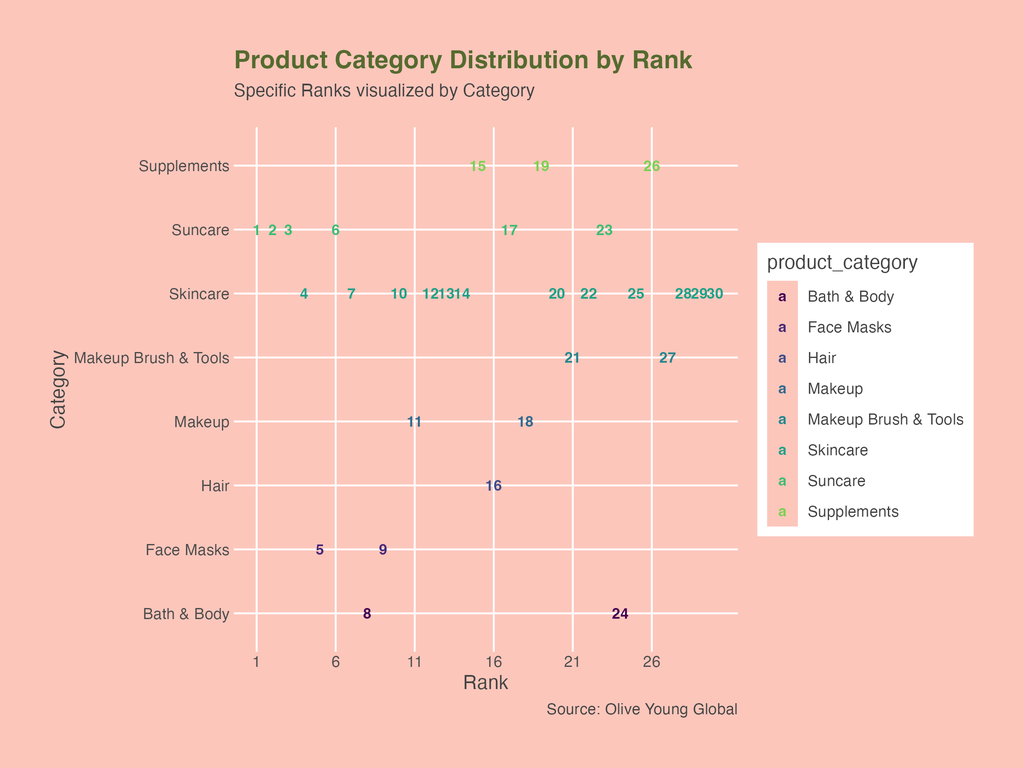

A text-based distribution chart showing bestseller ranks categorized by product type.

## Plot3. Promotion vs Price

Finally, I explored the impact of promotions on product prices. Products with at least one promotion were generally much cheaper than products without promotions. However, there was an interesting twist in the data. I originally expected that products with more promotions would always have lower prices, but products with three promotions actually had lower average prices than products with four promotions. This suggests that simply increasing the number of promotions may not always improve price competitiveness. Instead, strategically combining promotions depending on the product category or price range may be more effective.

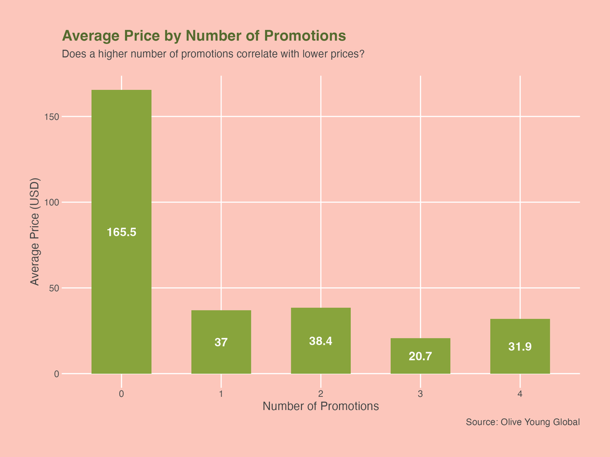

A bar chart comparing average prices based on the number of promotions applied